# `multinomial` vs `OneVsRestClassifier`

Czym się różni `LogisticRegression(multi_class='multinomial')` od `OneVsRestClassifier(LogisticRegression())` ?

Granica jest bardzo cienka i różnice są widoczne jedynie w kwestii budowy sklearn'a - `OneVsRestClassifier` to ogólny interfejs do budowania klasyfikatorów korzystających z strategii **OvR** a `LogisticRegression(multi_class='multinomial')` to praktycznie to samo, poza faktem że jest wyspecjalizowane do tego zadania. Według dokumentacji - korzysta z funkcji aktywacji `softmax` i funkcji kosztu `categorical crossentropy`, w przeciwieństwie do `OneVsRestClassifier` który trenuje kilka zwykłych klasyfikatorów do rozpoznawania każdej cechy.

```python
import keras
import matplotlib.pyplot as plt
import numpy as np
from IPython.display import display, Markdown
from keras.datasets import fashion_mnist

def displmd(*args, **kwargs):
    display(Markdown('\n\n'.join(arg for arg in args), **kwargs))
```

Po wczytaniu możemy podglądnąć obrazki w zbiorze danych, są one w skali szarości, 28x28 pikseli i przedstawiają ubrania z 10 klas. Po wczytaniu danych są one w kształcie `(X, 28, 28)`. gdzie X to rozmiar zbioru danych. W celu przetworzenia danych do postaci wektorowej, musimy je spłaszczyć do postaci `(X, 784)`. W tym celu możemy wykorzystać funkcję `reshape` z biblioteki numpy.

Image size: `(28, 28)`

Test set size: `10000`

Train set size: `60000`

Number of classes: `10`

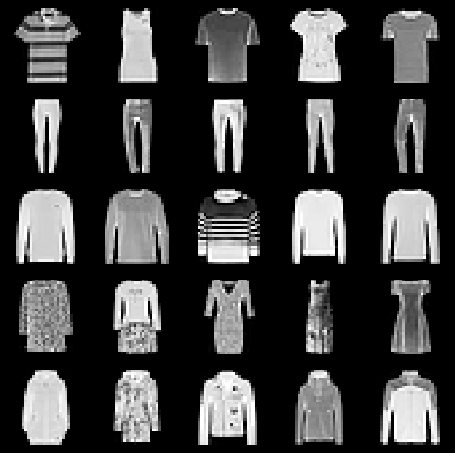

```python
(x_train, y_train), (x_test, y_test) = fashion_mnist.load_data()

displmd(f"## Image size: `{x_train[0].shape}`",
        f"## Test set size: `{len(x_test)}`",
        f"## Train set size: `{len(x_train)}`",
        f"## Number of classes: `{len(np.unique(y_train))}`")

# show ten random images, from each class

n_classes, n_samples = 5, 5
fig, axs = plt.subplots(n_classes, n_samples, figsize=(7, 7))
for i in range(n_classes):
    for j in range(n_samples):
        axs[i, j].imshow(x_train[np.random.choice(np.where(y_train == i)[0])], cmap='gray')
        axs[i, j].axis('off')

fig.patch.set_facecolor('black')
plt.show()
```

# sklearn baseline

Aby sprawdzić działanie `sklearna` zdefiniujmy sposób porównwania modeli i wytenujmy klasyfikator na domyślnych parametrach.

```python
from sklearn.metrics import confusion_matrix, ConfusionMatrixDisplay, accuracy_score

def validate(y_pred_test, y_pred_train):
    #y_test_pred = model.predict(x_test, batch_size=len(x_test)).argmax(axis=1)

    acc_val = accuracy_score(y_true=y_test, y_pred=y_pred_test)
    acc_tr = accuracy_score(y_true=y_train, y_pred=y_pred_train)

    displmd(f"## Test set accuracy: `{acc_val:.3f}`",
            f"## Train set accuracy: `{acc_tr:.3f}`")

    cm = confusion_matrix(y_test, y_pred_test)

    disp = ConfusionMatrixDisplay(confusion_matrix=cm, display_labels=np.unique(y_test))
    disp.plot()
```

Warto zwrócić uwagę że ustawienia są tutaj *bardzo* ważne. W tym przypadku, `solver` jakikolwiek niebędący `sag` znacząco obniża skuteczność klasyfikatora.

```python
from sklearn.linear_model import LogisticRegression

lr = LogisticRegression(verbose=1, max_iter=10, multi_class="multinomial", solver="sag", n_jobs=-1)

lr.fit(x_train.reshape((-1, 28*28)), y_train)
```

```
[Parallel(n_jobs=-1)]: Using backend ThreadingBackend with 8 concurrent workers.
```

```
max_iter reached after 14 seconds
```

```
LogisticRegression(max_iter=10, multi_class='multinomial', n_jobs=-1,
                   solver='sag', verbose=1)
```

Podan 84% skuteczności! Jest to fenomenalny wynik. Warto zwrócić uwagę że inny solver uzyskałby wynik około 3-5% niższy.

Test set accuracy: `0.842`

Train set accuracy: `0.870`

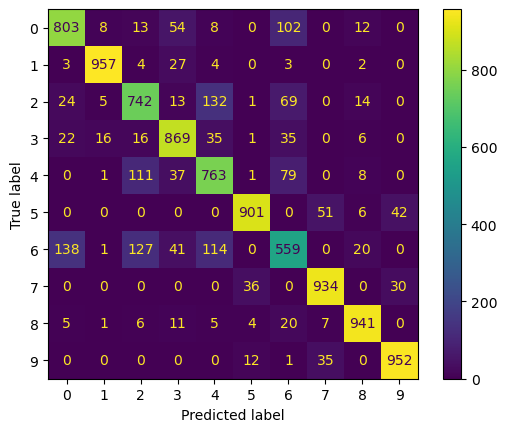

```python
validate(lr.predict(x_test.reshape((-1, 28*28))), lr.predict(x_train.reshape((-1, 28*28))))
```

```python
print(lr.intercept_.shape)
print(lr.coef_.shape)
```

```
(10,)
(10, 784)
```

Spróbujmy wytrenować klasyfikator ręcznie, definiując model, funkcje kosztu i optymalizator. Wykorzytsam do tego `keras`'a. Z dokumentacji wynika że `OneVsRestClassifier` działa tak że trenuje 10 sztuk klasifikatora LinearRegression posiadających normalne dla nich funkcje aktywacji (sigmoid). W przypadku `multinomial` z dokumentacji wynika że używa `softmax` jako funkcji aktywacji i `categorical_crossentropy` jako funkcji kosztu.

```python
from keras import layers
from keras import optimizers
from keras import losses
from keras.preprocessing import backend

from tqdm.keras import TqdmCallback

model = keras.models.Sequential([
    layers.Flatten(input_shape=(28, 28)),
    layers.ActivityRegularization(l2=0.5),
    layers.Dense(10, activation='sigmoid'),
])

model.summary()

model.compile(optimizer=optimizers.Adam(learning_rate=0.002), loss='categorical_crossentropy', metrics=['accuracy'])

history = model.fit(x_train, backend.one_hot(y_train, 10), epochs=100, batch_size=10000, validation_data=(x_test, backend.one_hot(y_test, 10)), verbose=0, callbacks=[TqdmCallback(verbose=0)])
```

```
Model: "sequential_7"
_________________________________________________________________
 Layer (type)                Output Shape              Param #
=================================================================
 flatten_7 (Flatten)         (None, 784)               0

 activity_regularization_7 (  (None, 784)              0
 ActivityRegularization)

 dense_7 (Dense)             (None, 10)                7850

=================================================================
Total params: 7,850
Trainable params: 7,850
Non-trainable params: 0
_________________________________________________________________
```

```
0epoch [00:00, ?epoch/s]
```

```
WARNING:tensorflow:Callback method `on_train_batch_end` is slow compared to the batch time (batch time: 0.0049s vs `on_train_batch_end` time: 0.0181s). Check your callbacks.
```

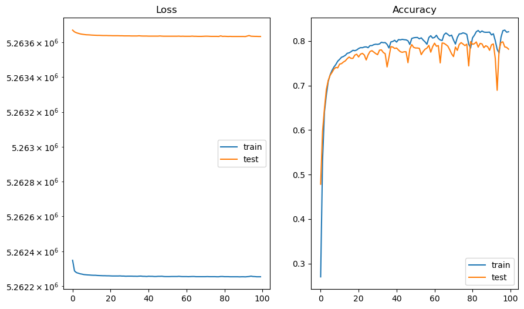

```python
fig, axs = plt.subplots(1, 2, figsize=(10, 6))
axs[0].plot(history.history['loss'], label='train')
axs[0].plot(history.history['val_loss'], label='test')
axs[0].set_title('Loss')
axs[0].set_yscale('log')
axs[0].legend()

axs[1].plot(history.history['accuracy'], label='train')
axs[1].plot(history.history['val_accuracy'], label='test')
axs[1].set_title('Accuracy')
axs[1].legend()

plt.show()
```

[output not shown]

Test set accuracy: `0.180`

Train set accuracy: `0.186`

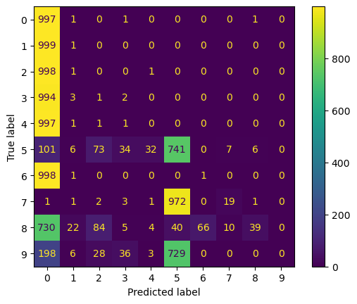

```python
validate(model.predict(x_test, batch_size=len(x_test)).argmax(axis=1), model.predict(x_train, batch_size=len(x_train)).argmax(axis=1))
```

```python
y_test_pred = model.predict(x_test, batch_size=len(x_test))

print(y_test_pred.shape)
print(y_test_pred[:4])
print(y_test_pred[:4].argmax(axis=1))
```

```
(10000, 10)
[[0.00000e+00 0.00000e+00 0.00000e+00 0.00000e+00 0.00000e+00 6.84514e-21
  0.00000e+00 0.00000e+00 0.00000e+00 0.00000e+00]
 [0.00000e+00 0.00000e+00 0.00000e+00 0.00000e+00 0.00000e+00 0.00000e+00
  0.00000e+00 0.00000e+00 0.00000e+00 0.00000e+00]
 [0.00000e+00 0.00000e+00 0.00000e+00 0.00000e+00 0.00000e+00 0.00000e+00
  0.00000e+00 0.00000e+00 0.00000e+00 0.00000e+00]
 [0.00000e+00 0.00000e+00 0.00000e+00 0.00000e+00 0.00000e+00 0.00000e+00
  0.00000e+00 0.00000e+00 0.00000e+00 0.00000e+00]]
[5 0 0 0]
```

# Single logistic classifier by learning probability distribution across multiple classes

Teraz wytrenujmy model tak jakby to zrobił LinearClassifier z `multi_class='multinomial'`. W tym celu wykorzytsamy `softmax` jako funkcję aktywacji i `categorical_crossentropy` jako funkcję kosztu. Dodatkowo nalezy dodać regularyzację L2. Wytrenujmy model na losowych hiperparametrach.

```python
#  Single logistic classifier by learning probability distribution across multiple classes
# multi_class_cifar10_classifier = LogisticRegression(verbose=1, max_iter=10, multi_class="multinomial", solver="sag")
def gen_model2(l2=0.0, lr=0.001):
    m = keras.models.Sequential([
        layers.Flatten(input_shape=(28, 28)),
        layers.Dense(10, activation='softmax', kernel_regularizer=keras.regularizers.l2(l2)),
    ])

    m.compile(optimizer=optimizers.Adam(learning_rate=lr), loss='sparse_categorical_crossentropy', metrics=['accuracy'])

    return m

model2 = gen_model2(0.5, 0.0005)
history2 = model2.fit(x_train, y_train, epochs=100, batch_size=10000, validation_data=(x_test, y_test), verbose=0, callbacks=[TqdmCallback(verbose=0)])
```

```
0epoch [00:00, ?epoch/s]
```

```
WARNING:tensorflow:Callback method `on_train_batch_end` is slow compared to the batch time (batch time: 0.0038s vs `on_train_batch_end` time: 0.0048s). Check your callbacks.
```

Test set accuracy: `0.770`

Train set accuracy: `0.785`

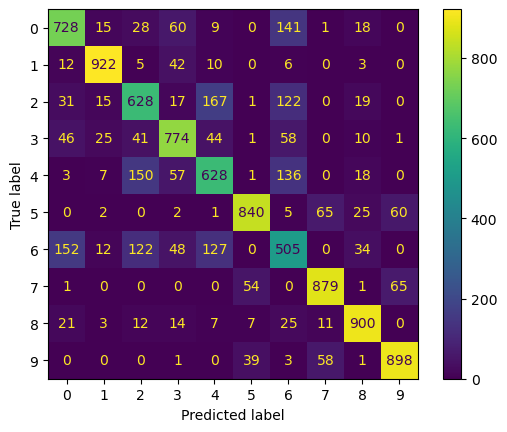

```python
validate(model2.predict(x_test, batch_size=len(x_test)).argmax(axis=1), model2.predict(x_train, batch_size=len(x_train)).argmax(axis=1))
```

Jak widać, nie radzi sobie za dobrze. Dlatego sprawdźmy wiele kombinacji hiperparametrów aby znaleść te najlepsze i na nich wytrenować model.

```python
from keras.wrappers.scikit_learn import KerasClassifier
from sklearn.model_selection import RandomizedSearchCV
from scipy.stats import reciprocal

keras_c = KerasClassifier(gen_model2)

params = {
    "l2": reciprocal(3e-2, 1),
    "lr": reciprocal(3e-5, 3e-2),
    "batch_size": [512, 1024, 2048, 4096, 8192],
    "epochs": [50, 100, 150, 200],
}

rnd_cv = RandomizedSearchCV(keras_c, params, n_iter=10, cv=3, scoring='accuracy')

output = rnd_cv.fit(x_train, y_train, validation_data=(x_test, y_test), validation_batch_size=len(x_test), verbose=0, callbacks = [keras.callbacks.EarlyStopping(patience=10)])
```

```
{'batch_size': 8192, 'epochs': 50, 'l2': 0.08409641627355649, 'lr': 0.019693570289494835}
0.8075666666666667
```

Test set accuracy: `0.765`

Train set accuracy: `0.784`

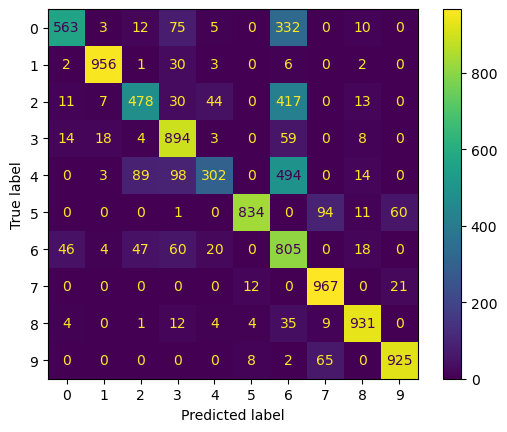

```python
print(rnd_cv.best_params_)
print(rnd_cv.best_score_)

model3 = rnd_cv.best_estimator_
validate(model3.predict(x_test, batch_size=len(x_test)), model3.predict(x_train, batch_size=len(x_train)))
```

Ok. Nasz model radzi sobie całkiem źle **ale**, jest to efekt uboczny `cv=3` który trenuje model na cześci zbioru. Pokażmy mu cały zbiór i zobaczmy jak radzi sobie.

```
0epoch [00:00, ?epoch/s]
```

Test set accuracy: `0.820`

Train set accuracy: `0.846`

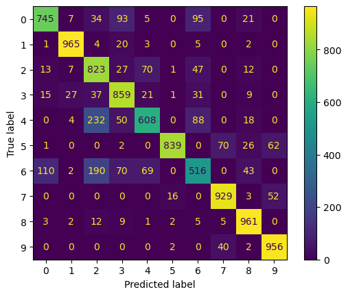

```python
model_bestparams = gen_model2(rnd_cv.best_params_["l2"], rnd_cv.best_params_["lr"])

model_bestparams.fit(x_train, y_train, batch_size=rnd_cv.best_params_["batch_size"], epochs=300, validation_data=(x_test, y_test), verbose=0, callbacks=[TqdmCallback(verbose=0)])

validate(model_bestparams.predict(x_test, batch_size=len(x_test)).argmax(axis=1), model_bestparams.predict(x_train, batch_size=len(x_train)).argmax(axis=1))
```

Nie jest źle, ale jest to wynik gorszy od `sklearn`'a - dla przypomnienia

```python
displmd(f"### Wynik sklearn'a: `{accuracy_score(y_test, lr.predict(x_test.reshape((-1, 28*28))))}`" )
```

[output not shown]

Może to wynikać z innego standardu uczenia albo z innego sposobu trenowania. W każdym razie, `sklearn` radzi sobie w tym przypadku lepiej, chociaż keras z odpowiedną troską zapewne uzyskał by taki sam wynik.